# General 02: Getting Started with Statistical Analysis for Pathologists

ClinicoPath Development Team

2025-06-30

## 1 Introduction

ClinicoPathDescriptives is a comprehensive R package designed for descriptive analysis in clinicopathological research. It provides both programmatic R functions and a graphical user interface through jamovi, making advanced statistical analysis accessible to researchers with varying levels of programming experience.

### 1.1 Key Features

- **Descriptive Statistics**: Generate comprehensive “Table One” summaries
- **Cross-tabulations**: Create contingency tables with appropriate statistical tests
- **Visualization Tools**: Age pyramids, alluvial diagrams, Venn diagrams, and more
- **Treatment Response Analysis**: Waterfall and swimmer plots for oncology research
- **Data Quality Assessment**: Benford’s law analysis for fraud detection
- **Dual Interface**: Use in R or through jamovi’s point-and-click interface

## 2 Installation

### 2.1 Install from GitHub

```r
# Install development version
if (!require("remotes")) install.packages("remotes")
remotes::install_github("sbalci/ClinicoPathDescriptives")
```

### 2.2 Install as jamovi Module

Download the `.jmo` file from [Releases](https://github.com/sbalci/ClinicoPathDescriptives/releases) and install in jamovi via: `jamovi menu > Modules > Install from file`

## 3 Loading the Package

```r
library(ClinicoPath)
library(dplyr)    # For data manipulation
library(ggplot2)  # For additional plotting
```

## 4 Example Dataset

The package includes a comprehensive histopathology dataset with 250 cancer patients and 38 variables including demographics, pathological features, biomarkers, and outcomes.

```r
# Load the example dataset
data(histopathology)

# Examine the structure
str(histopathology, give.attr = FALSE)
```

```
#> spc_tbl_ [250 × 38] (S3: spec_tbl_df/tbl_df/tbl/data.frame)
#>  $ ID                  : num [1:250] 1 2 3 4 5 6 7 8 9 10 ...
#>  $ Name                : chr [1:250] "Tonisia" "Daniyah" "Naviana" "Daerion" ...
#>  $ Sex                 : chr [1:250] "Male" "Female" "Male" "Male" ...
#>  $ Age                 : num [1:250] 27 36 65 51 58 53 33 26 25 68 ...
#>  $ Race                : chr [1:250] "White" "White" "White" "White" ...
#>  $ PreinvasiveComponent: chr [1:250] "Present" "Absent" "Absent" "Absent" ...
#>  $ LVI                 : chr [1:250] "Present" "Absent" "Absent" "Present" ...
#>  $ PNI                 : chr [1:250] "Absent" "Absent" "Absent" "Absent" ...
#>  $ LastFollowUpDate    : chr [1:250] "2019.10.22 00:00:00" "2019.06.22 00:00:00" "2019.08.22 00:00:00" "2019.03.22 00:00:00" ...
#>  $ Death               : chr [1:250] "YANLIŞ" "DOĞRU" "DOĞRU" "YANLIŞ" ...
#>  $ Group               : chr [1:250] "Control" "Treatment" "Control" "Treatment" ...
#>  $ Grade               : num [1:250] 2 2 1 3 2 2 1 2 3 3 ...
#>  $ TStage              : num [1:250] 4 4 4 4 1 4 2 3 4 4 ...
#>  $ Anti-X-intensity    : num [1:250] 3 2 2 3 3 3 2 2 1 2 ...
```

[output cut: 24 more lines]

```r
# Quick overview of key variables
histopathology %>%
  select(Age, Sex, Grade, TStage, Group, Outcome, OverallTime) %>%
  head(10)
```

```
#> # A tibble: 10 × 7
#>      Age Sex    Grade TStage Group     Outcome OverallTime
#>    <dbl> <chr>  <dbl>  <dbl> <chr>       <dbl>       <dbl>
#>  1    27 Male       2      4 Control         0         3.5
#>  2    36 Female     2      4 Treatment       1         3.1
#>  3    65 Male       1      4 Control         1         3.1
#>  4    51 Male       3      4 Treatment       0         4.9
#>  5    58 Female     2      1 Treatment       0         3.3
#>  6    53 Female     2      4 Treatment       0         9.3
#>  7    33 Male       1      2 Treatment       1         6.3
#>  8    26 Male       2      3 Treatment       1         9
#>  9    25 Female     3      4 Treatment       1         5.8
#> 10    68 Female     3      4 Control         0         9.9
```

## 5 Basic Descriptive Analysis

### 5.1 Table One

Generate a comprehensive descriptive summary table - the cornerstone of clinical research manuscripts:

```r
# Basic Table One
tableone(
  data = histopathology,
  vars = c("Age", "Sex", "Grade", "TStage", "LVI", "PNI")
)
```

```
#>
#>  TABLE ONE
#>
#> character(0)
#>
#>                      Overall
#>   n                    250
#>   Age (mean (SD))    49.44 (13.81)
#>   Sex = Male (%)       128 (51.4)
#>   Grade (mean (SD))   2.10 (0.83)
#>   TStage (mean (SD))  3.05 (1.02)
#>   LVI = Present (%)    106 (42.6)
#>   PNI = Present (%)     83 (33.3)
```

### 5.2 Continuous Variables Summary

Generate detailed summaries for continuous variables:

```r
summarydata(
  data = histopathology,
  vars = c("Age", "OverallTime", "MeasurementA"),
  date_vars = NULL,
  grvar = "Grade"
)
```

[output not shown]

[output cut: 793 more lines]

[output not shown]

### 5.3 Categorical Variables Summary

Analyze categorical variables with counts and percentages:

```r
reportcat(
  data = histopathology,
  vars = c("Sex", "Grade", "TStage", "LVI", "PNI")
)
```

[output not shown]

[output cut: 735 more lines]

[output not shown]

## 6 Cross-tabulation Analysis

Create contingency tables with appropriate statistical tests:

```r
crosstable(
  data = histopathology,
  vars = "Grade",
  group = "Group"
)
```

[output not shown]

[output cut: 53 more lines]

[output not shown]

```r
# Multiple variables cross-tabulation
crosstable(
  data = histopathology,
  vars = c("Grade", "TStage"),
  group = "LymphNodeMetastasis"
)
```

[output not shown]

[output cut: 57 more lines]

[output not shown]

## 7 Data Visualization

### 7.1 Age Pyramid

Visualize age and sex distribution:

```
#>
#>  AGE PYRAMID
#>
#>  Population Data
#>  ────────────────────────────────
#>    Population    Female    Male
#>  ────────────────────────────────
#>    (70,73]            8       5
#>    (65,70]           17      11
#>    (60,65]           16      10
#>    (55,60]           14      17
#>    (50,55]            8      11
#>    (45,50]            8      15
#>    (40,45]           19      14
#>    (35,40]           13      15
#>    (30,35]            6      13
#>    (25,30]           10      17
#>    (20,25]            1       0
#>  ────────────────────────────────
```

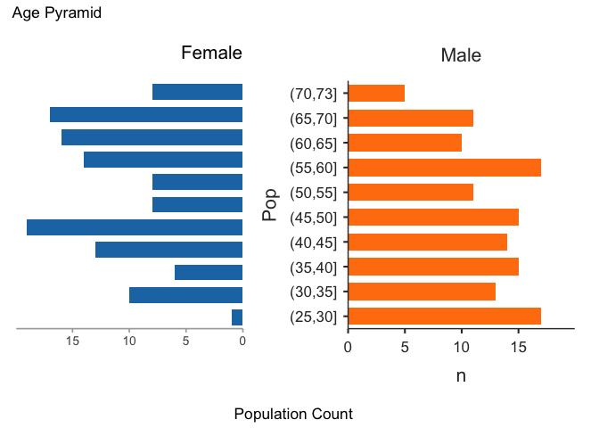

```r
agepyramid(
  data = histopathology,
  age = "Age",
  gender = "Sex",
  female = "Female"
)
```

### 7.2 Alluvial Diagrams

Show relationships between categorical variables:

```
#>
#>  ALLUVIAL DIAGRAMS
#>
#> character(0)
#> [1] "Number of flows: 49"
#> [1] "Original Dataframe reduced to 19.6 %"
#> [1] "Maximum weight of a single flow 5.6 %"
```

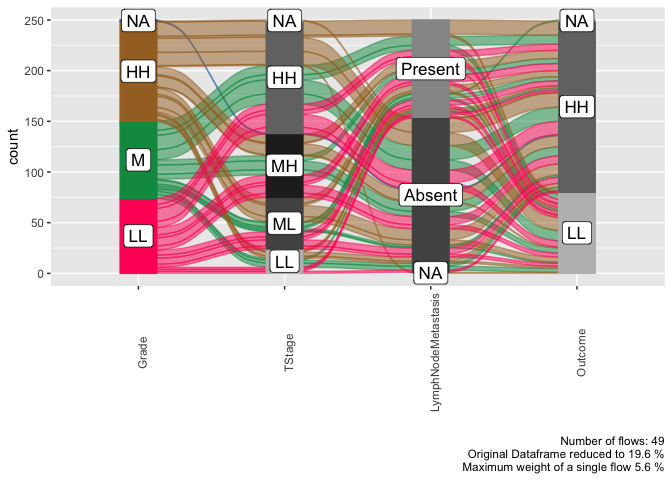

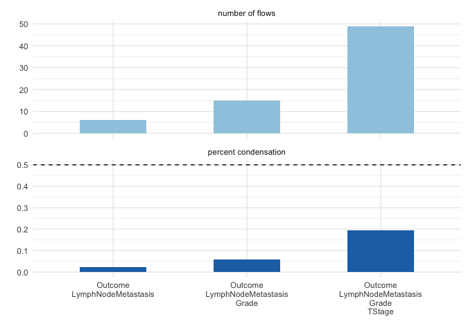

```r
alluvial(
  data = histopathology,
  vars = c("Grade", "TStage", "LymphNodeMetastasis", "Outcome"),
  condensationvar = "Outcome"
)
```

### 7.3 Venn Diagrams

Analyze overlap between sets:

```
#>
#>  VENN DIAGRAM
#>
#> character(0)
```

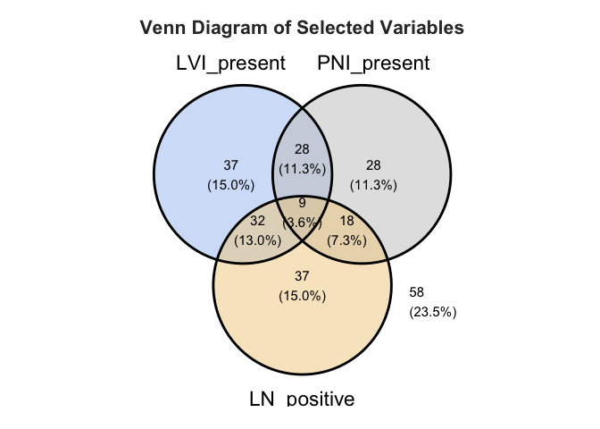

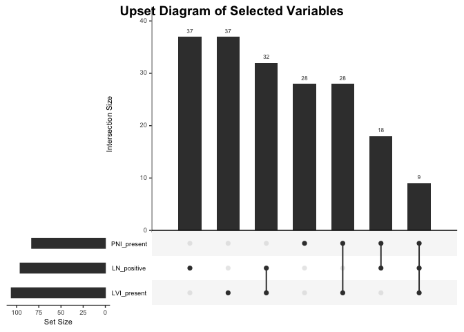

```r
# Create binary indicators for Venn diagram
histopathology_venn <- histopathology %>%
  mutate(
    LVI_present = ifelse(LVI == "Present", 1, 0),
    PNI_present = ifelse(PNI == "Present", 1, 0),
    LN_positive = ifelse(LymphNodeMetastasis == "Present", 1, 0)
  )

venn(
  data = histopathology_venn,
  var1 = "LVI_present",
  var1true = 1,
  var2 = "PNI_present",
  var2true = 1,
  var3 = "LN_positive",
  var3true = 1,
  var4 = NULL,
  var4true = NULL
)
```

## 8 Data Quality Assessment

### 8.1 Benford’s Law Analysis

Assess data quality using Benford’s law - useful for detecting fabricated data:

```
#>
#>  BENFORD ANALYSIS
#>
#>  See
#>  <a href = 'https://github.com/carloscinelli/benford.analysis'>Package
#>  documentation for interpratation.
#>
#> Benford object:
#>
#> Data: var
#> Number of observations used = 135
#> Number of obs. for second order = 134
#> First digits analysed = 2
#>
#> Mantissa:
#>
#>    Statistic  Value
#>         Mean  0.506
#>          Var  0.108
#>  Ex.Kurtosis -1.514
#>     Skewness -0.037
#>
#>
#> The 5 largest deviations:
#>
#>   digits absolute.diff
#> 1     52          4.88
#> 2     17          4.65
#> 3     66          4.12
#> 4     13          3.66
#> 5     16          3.55
#>
#> Stats:
#>
#>  Pearson's Chi-squared test
#>
#> data:  var
#> X-squared = 137.97, df = 89, p-value = 0.0006808
#>
#>
```

[output cut: 10 more lines]

[output not shown]

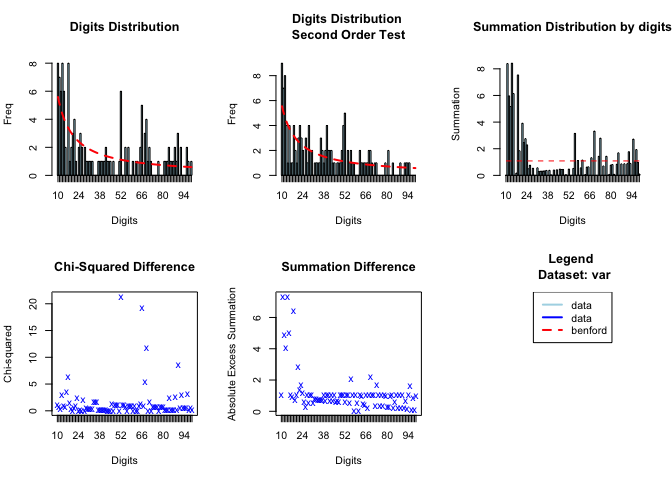

[output not shown]

[output cut: 142 more lines]

[output not shown]

```r
# Analyze first digits of continuous measurements
benford(
  data = histopathology,
  var = "MeasurementA"
)
```

### 8.2 Variable Tree Summary

Get a hierarchical overview of your dataset:

```r
# Variable tree visualization example
# Note: vartree requires specific parameter configuration for optimal results
# This is a demonstration of the function call structure
vartree_result <- vartree(
  data = histopathology,
  vars = c("Grade", "TStage", "LVI", "PNI"),
  percvar = NULL,
  percvarLevel = NULL,
  summaryvar = NULL,
  prunebelow = NULL,
  pruneLevel1 = NULL,
  pruneLevel2 = NULL,
  follow = NULL,
  followLevel1 = NULL,
  followLevel2 = NULL,
  excl = FALSE,
  vp = TRUE,
  horizontal = FALSE,
  sline = TRUE,
  varnames = FALSE,
  nodelabel = TRUE,
  pct = FALSE
)

# For detailed vartree examples, see the vartree-specific vignette
cat("Variable tree visualization complete. See vartree documentation for advanced usage.")
```

[output not shown]

## 9 Working with Treatment Response Data

Load the treatment response dataset for oncology-specific analyses:

```r
# Load treatment response data
data(treatmentResponse)
if(exists("treatmentResponse")) {
  head(treatmentResponse)
} else {
  cat("treatmentResponse dataset not found. Using histopathology dataset instead.\n")
  head(histopathology)
}
```

```
#>   PatientID ResponseValue
#> 1    PT0001          63.5
#> 2    PT0002        -100.0
#> 3    PT0003         -20.5
#> 4    PT0004          55.1
#> 5    PT0005         -60.5
#> 6    PT0006         -93.6
```

### 9.1 Waterfall Plot

Visualize individual patient treatment responses:

```r
# Waterfall plot example (requires proper treatmentResponse dataset)
if(exists("treatmentResponse") && "PatientID" %in% names(treatmentResponse)) {
  waterfall(
    data = treatmentResponse,
    patientID = "PatientID",
    responseVar = "ResponseValue"
  )
} else {
  cat("Waterfall plot requires treatmentResponse dataset with PatientID and ResponseValue columns.\n")
  cat("See waterfall vignette for detailed examples with proper data structure.\n")
}
```

[output not shown]

## 10 Integration with jamovi

All functions in this package are also available through jamovi’s graphical interface:

1. **Install the module** in jamovi
2. **Navigate to**: `Exploration > ClinicoPath Descriptives`
3. **Select your analysis** function
4. **Configure options** through the GUI
5. **Generate results** with point-and-click ease

### 10.1 jamovi Advantages

- No programming required
- Interactive parameter adjustment
- Real-time result updates
- Export capabilities for reports
- Accessible to non-programmers

## 11 Next Steps

This vignette covered the basic functionality of ClinicoPathDescriptives. For more advanced usage, see:

- **Clinical Workflow Vignette**: Complete analysis workflows for clinical research
- **Treatment Response Analysis**: Advanced oncology analysis techniques
- **Data Quality and Exploration**: Comprehensive data assessment methods
- **Visualization Gallery**: Advanced plotting techniques and customization

## 12 Citation

```r
citation("ClinicoPathDescriptives")
```

## 13 Support

- 📖 [Documentation](https://www.serdarbalci.com/ClinicoPathDescriptives/)
- 🐛 [Report Issues](https://github.com/sbalci/ClinicoPathJamoviModule/issues)
- 🌐 [jamovi Module Hub](https://sbalci.github.io/ClinicoPathJamoviModule/)